# Acanthophora spicifera Ek lmm

Angela Richards Donà

2024-05-15

## Acanthophora Ek Linear Mixed Effects Model Analysis

This is the analysis of two runs of Acanthophora spicifera salinity and nutrient experiments conducted on the lanai in St. John 616 in November and December 2023. These experiments incorporated two salinity/nutrient levels and two temperature levels. Ek is here used for these analyses. ek.est = Ek estimate - terminology from WebFitt model that produced the values on Phytotools package

```r
library(lme4)
library(lmerTest)
library(afex)
library(effects)
library(car)
library(MuMIn)
library (dplyr)
library(emmeans)
library(DHARMa)
library(performance)
library(patchwork)
library(rstatix)
#for plots and tables
library(ggplot2)
library(ggpubr)
library(forcats)
library(RColorBrewer)
library(tidyverse)
library(sjPlot)
library(sjmisc)
#library(mmtable2)
library(gt)
library(purrr)
library(stringr)
library(tidyr)
```

Load this file for normalized to quantum efficiency of photosynthesis per Silsbe and Kromkamp

```r
acan_ps <- read.csv("../transformed/acan_ek_alpha_normalized_2024.csv")
```

Assign run as a factor

```r
acan_ps$run <- as.factor(acan_ps$run)
```

Assign temperature as a factor

```r
acan_ps$temp <- as.factor(acan_ps$temp)
```

Assigns treatment as characters from integers then to factors

```r
acan_ps$treatment <- as.factor(as.character(acan_ps$treatment))
```

Add tags for treatments. Use Day 9 for final analysis

```r
acan_day9 <- subset(acan_ps, rlc_day == 9)
acan_day9$treatment_graph[acan_day9$treatment == 0] <- "1) 35ppt/0.5umol"
acan_day9$treatment_graph[acan_day9$treatment == 1] <- "2) 28ppt/14umol"

acan_day9$temperature_graph[acan_day9$temp == 24] <- "24°C"
acan_day9$temperature_graph[acan_day9$temp == 28] <- "28°C"
```

Plot histograms

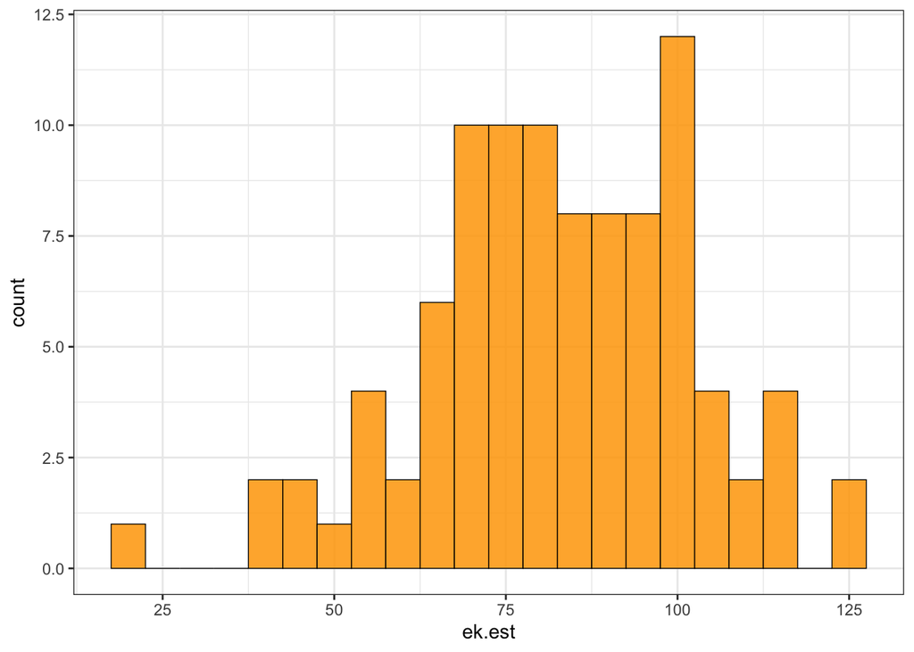

```r
acan_day9 %>% ggplot(aes(ek.est)) +
  geom_histogram(binwidth=5, fill = "orange", color = "black", linewidth = 0.25, alpha = 0.85) +
  theme_bw()
```

Run model

```r
acan_day9_ek.est_model <- lmer(formula = ek.est ~ treatment + temp + (1 | run) + (1 | plantID) + (1 | rlc_order), data = acan_day9)
```

Construct null model to perform likelihood ratio test REML must be FALSE

```r
acan_ek.est_treatment_null <- lmer(formula = ek.est ~ temp + (1 | run) + (1 | plantID) + (1 | rlc_order), data = acan_day9, REML = FALSE)
acan_ek.est_model2 <- lmer(formula = ek.est ~ treatment + temp + (1 | run) + (1 | plantID) + (1 | rlc_order), data = acan_day9, REML = FALSE)
anova(acan_ek.est_treatment_null, acan_ek.est_model2)
```

```
## Data: acan_day9
## Models:
## acan_ek.est_treatment_null: ek.est ~ temp + (1 | run) + (1 | plantID) + (1 | rlc_order)
## acan_ek.est_model2: ek.est ~ treatment + temp + (1 | run) + (1 | plantID) + (1 | rlc_order)
##                            npar    AIC    BIC  logLik deviance  Chisq Df
## acan_ek.est_treatment_null    6 820.47 835.85 -404.23   808.47
## acan_ek.est_model2            7 822.00 839.95 -404.00   808.00 0.4704  1
##                            Pr(>Chisq)
## acan_ek.est_treatment_null
## acan_ek.est_model2             0.4928
```

```r
acan_ek.est_temperature_null <- lmer(formula = ek.est ~ treatment + (1 | run) + (1 | plantID) + (1 | rlc_order), data = acan_day9, REML = FALSE)
acan_ek.est_model3 <- lmer(formula = ek.est ~ treatment + temp + (1 | run) + (1 | plantID) + (1 | rlc_order), data = acan_day9, REML = FALSE)
anova(acan_ek.est_temperature_null, acan_ek.est_model3)
```

```
## Data: acan_day9
## Models:
## acan_ek.est_temperature_null: ek.est ~ treatment + (1 | run) + (1 | plantID) + (1 | rlc_order)
## acan_ek.est_model3: ek.est ~ treatment + temp + (1 | run) + (1 | plantID) + (1 | rlc_order)
##                              npar    AIC    BIC  logLik deviance  Chisq Df
## acan_ek.est_temperature_null    6 832.11 847.50 -410.06   820.11
## acan_ek.est_model3              7 822.00 839.95 -404.00   808.00 12.115  1
##                              Pr(>Chisq)
## acan_ek.est_temperature_null
## acan_ek.est_model3            0.0005001 ***
## ---
## Signif. codes:  0 '***' 0.001 '**' 0.01 '*' 0.05 '.' 0.1 ' ' 1
```

Make residual plots of the data for Acanthophora

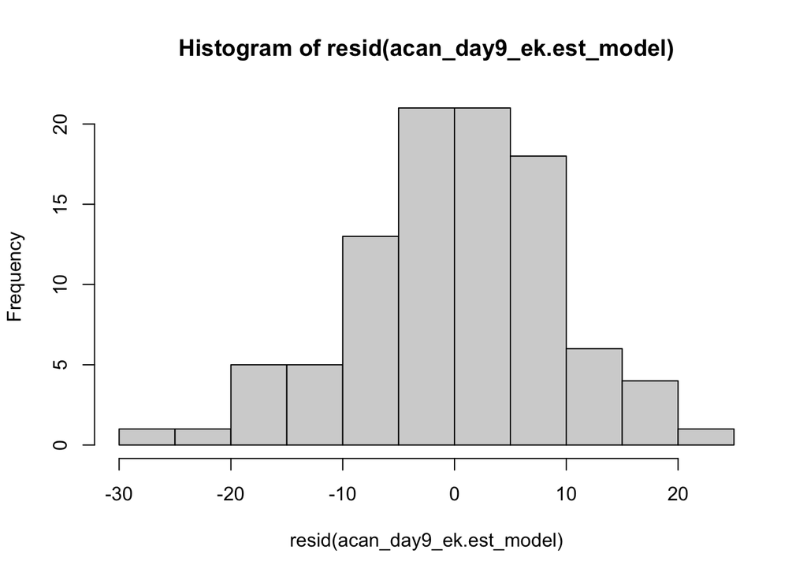

```r
hist(resid(acan_day9_ek.est_model))
```

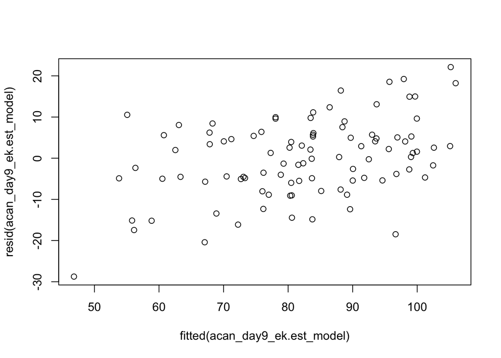

```r
plot(resid(acan_day9_ek.est_model) ~ fitted(acan_day9_ek.est_model))
```

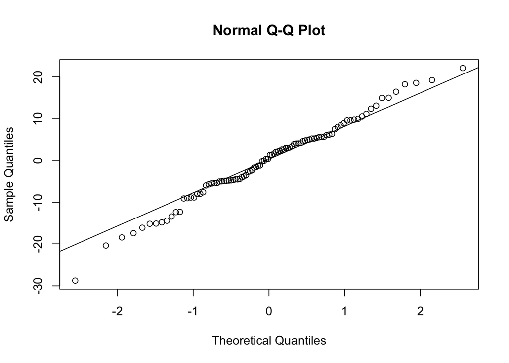

```r
qqnorm(resid(acan_day9_ek.est_model))
qqline(resid(acan_day9_ek.est_model))
```

Check the performance of the model

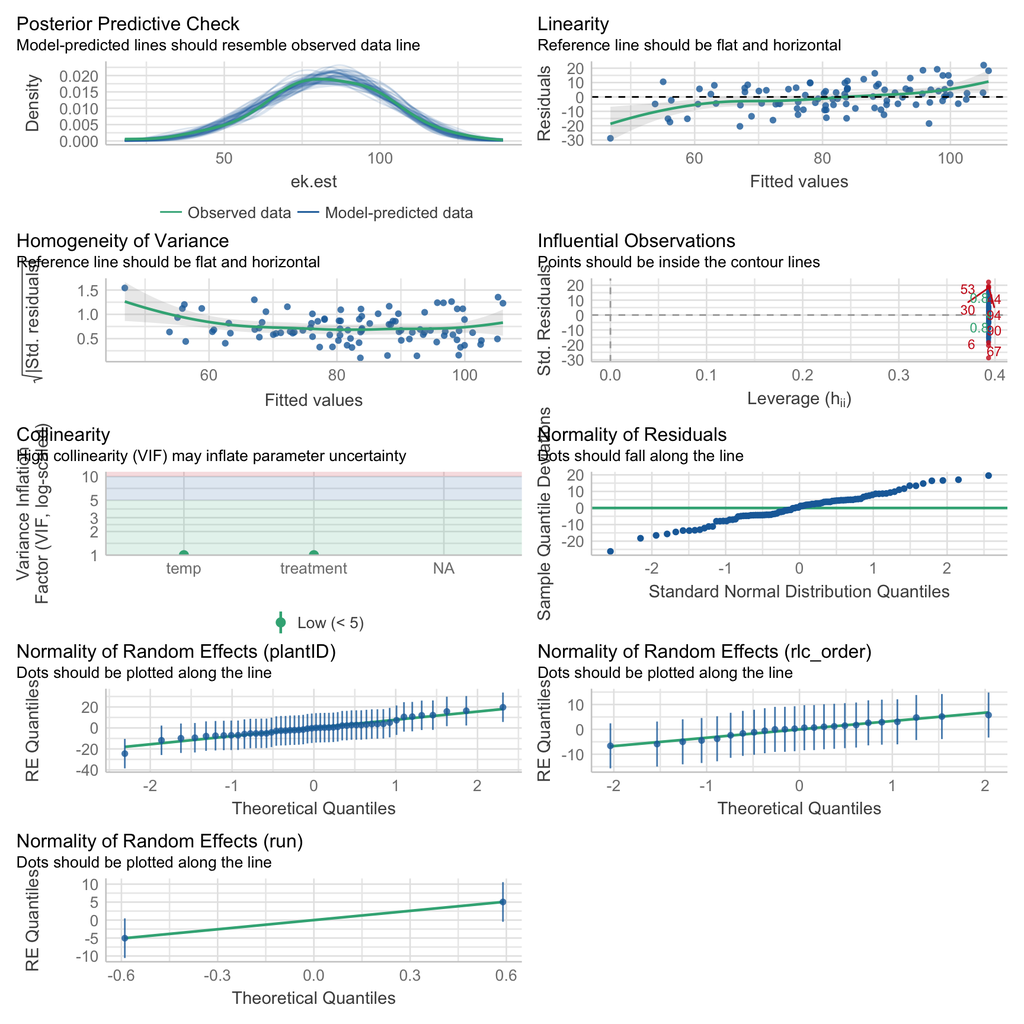

```r
performance::check_model(acan_day9_ek.est_model)
```

```r
r.squaredGLMM(acan_day9_ek.est_model)
```

```
##            R2m       R2c
## [1,] 0.1729027 0.6571542
```

````
Make plots and tables for the data

```r
tab_model(acan_day9_ek.est_model, show.intercept = TRUE, show.se = TRUE, show.stat = TRUE, show.df = TRUE, show.zeroinf = TRUE)
````

|  | ek.est |  |  |  |  |  |
| --- | --- | --- | --- | --- | --- | --- |
| Predictors | Estimates | std. Error | CI | Statistic | p | df |
| (Intercept) | 89.79 | 6.51 | 76.86 – 102.71 | 13.80 | **<0.001** | 89.00 |
| treatment [1] | 2.23 | 3.41 | -4.54 – 9.01 | 0.65 | 0.514 | 89.00 |
| temp [28] | -16.90 | 4.60 | -26.05 – -7.76 | -3.67 | **<0.001** | 89.00 |
| Random Effects |  |  |  |  |  |  |
| σ<sup>2</sup> | 145.59 |  |  |  |  |  |
| τ<sub>00</sub> <sub>plantID</sub> | 114.59 |  |  |  |  |  |
| τ<sub>00</sub> <sub>rlc_order</sub> | 33.41 |  |  |  |  |  |
| τ<sub>00</sub> <sub>run</sub> | 57.64 |  |  |  |  |  |
| ICC | 0.59 |  |  |  |  |  |
| N <sub>run</sub> | 2 |  |  |  |  |  |
| N <sub>plantID</sub> | 48 |  |  |  |  |  |
| N <sub>rlc_order</sub> | 24 |  |  |  |  |  |
| Observations | 96 |  |  |  |  |  |
| Marginal R<sup>2</sup> / Conditional R<sup>2</sup> | 0.173 / 0.657 |  |  |  |  |  |

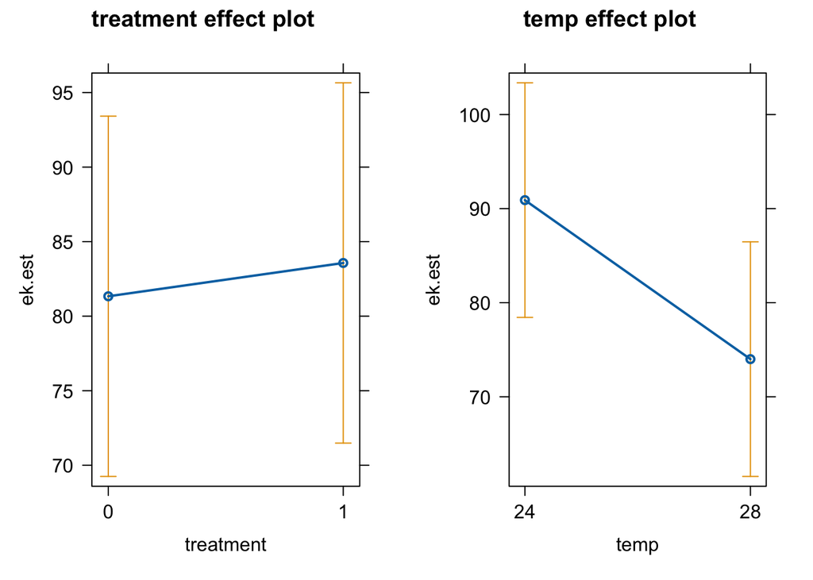

```r
plot(allEffects(acan_day9_ek.est_model))
```

Plot data

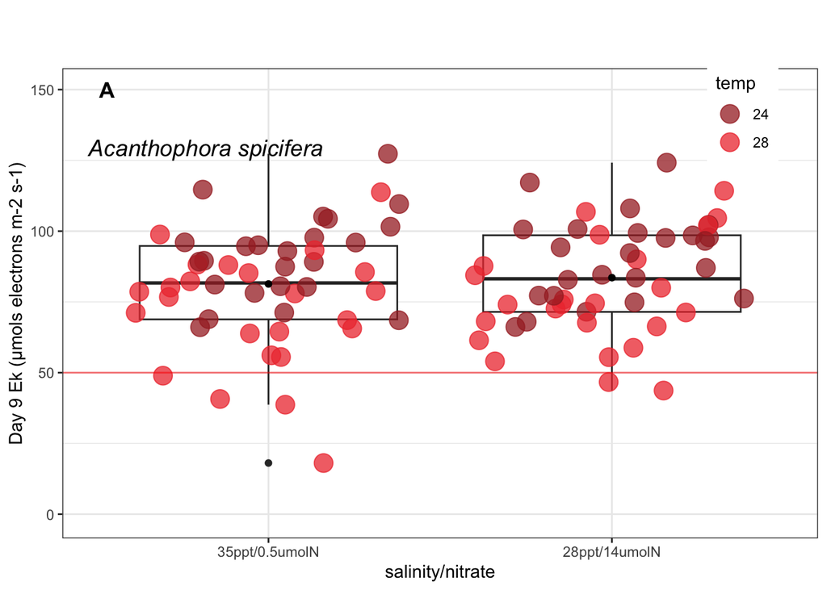

```r
acan_day9 %>% ggplot(aes(treatment_graph, ek.est)) +
  geom_boxplot(size=0.5) +
  geom_point(alpha = 0.75, size = 5, aes(color = temp), position = "jitter", show.legend = TRUE) +
  labs(x="salinity/nitrate", y= "Day 9 Ek (μmols electrons m-2 s-1)", title= "A", subtitle = "Acanthophora spicifera") +
  scale_x_discrete(labels = c("35ppt/0.5umolN", "28ppt/14umolN")) +
  ylim(-1, 150) + stat_mean() +
  scale_color_manual(values = c("brown", "brown2")) +
  geom_hline(yintercept=50, color = "red", size = 0.5, alpha = 0.5) +
  theme_bw() +
  theme(legend.position = c(0.90,0.90), plot.title = element_text(face = "bold", vjust = -15, hjust = 0.05),
        plot.subtitle = element_text(face = "italic", size = 14, vjust = -20, hjust = 0.05))
```

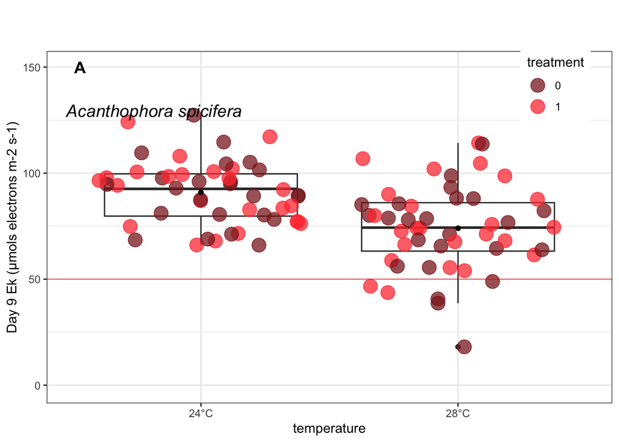

```r
acan_day9 %>% ggplot(aes(temperature_graph, ek.est)) +
  geom_boxplot(size=0.5) +
  geom_point(alpha = 0.75, size = 5, aes(color = treatment), position = "jitter", show.legend = TRUE) +
  labs(x="temperature", y= "Day 9 Ek (μmols electrons m-2 s-1)", title= "A", subtitle = "Acanthophora spicifera") +
  ylim(-1, 150) + stat_mean() +
  scale_color_manual(values = c("brown4", "brown1")) +
  geom_hline(yintercept=50, color = "red", size = 0.5, alpha = 0.5) +
  theme_bw() +
  theme(legend.position = c(0.90,0.90), plot.title = element_text(face = "bold", vjust = -15, hjust = 0.05),
        plot.subtitle = element_text(face = "italic", size = 14, vjust = -20, hjust = 0.05))
```

Summarize the means for ek.est

```r
acan_day9 %>% group_by(treatment) %>% summarise_at(vars(ek.est), list(mean = mean))
```

```
## # A tibble: 2 × 2
##   treatment  mean
##   <fct>     <dbl>
## 1 0          81.3
## 2 1          83.6
```

```r
acan_day9 %>% group_by(temp) %>% summarise_at(vars(ek.est), list(mean = mean))
```

```
## # A tibble: 2 × 2
##   temp   mean
##   <fct> <dbl>
## 1 24     90.9
## 2 28     74.0
```

## Linear regression Ek vs Growth and Ek vs Apices/Axis——————————————————–

Add growth rate from other dataset to this one and subset by species

```r
growth_rate <- read.csv("../input/acanthophora_growth_r1.csv")
growth_rate$treatment <- as.factor(growth_rate$treatment)
```

Make a new column for weight change (difference final from initial)

```r
growth_rate$growth_rate_percent <- (growth_rate$final_weight - growth_rate$initial_weight) / growth_rate$initial_weight * 100
acan_day9$growth_rate <- growth_rate$growth_rate_percent
acan_day9$mean_apices_per_axis <- growth_rate$mean_apices_per_axis
```

Plot a regression between the photosynthetic independent variables of interest and growth rate

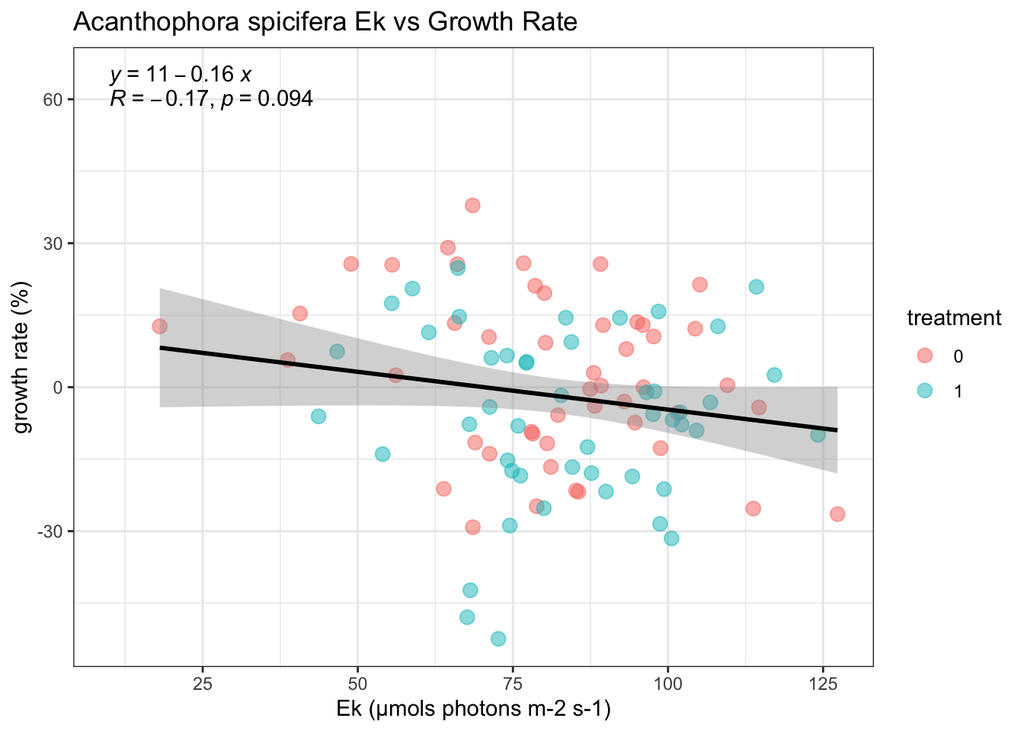

```r
acan_growth_ek.est_graph <- ggplot(acan_day9, aes(x=ek.est, y=growth_rate)) +
  geom_point(alpha = 0.5, size = 3, show.legend = TRUE, aes(color = treatment)) +
  geom_smooth(method = "lm", col = "black") + theme_bw() +
  labs(title = "Acanthophora spicifera Ek vs Growth Rate", x = "Ek (μmols photons m-2 s-1)",
       y = "growth rate (%)") + stat_regline_equation(label.x = 10, label.y = 65) + stat_cor(label.x = 10, label.y = 60)
acan_growth_ek.est_graph
```

Plot a regression between the photosynthetic independent variables of interest and apices/axis

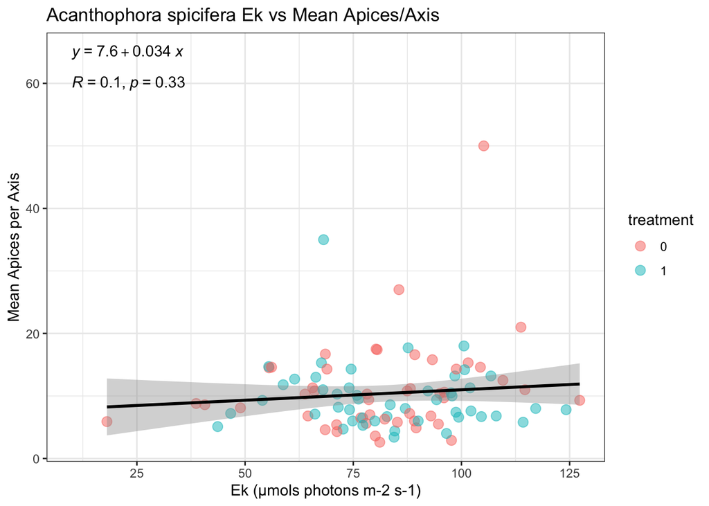

```r
acan_apices_ek_graph <- ggplot(acan_day9, aes(x=ek.est, y=mean_apices_per_axis)) +
  geom_point(alpha = 0.5, size = 3, show.legend = TRUE, aes(color = treatment)) +
  geom_smooth(method = "lm", col = "black") + theme_bw() +
  labs(title = "Acanthophora spicifera Ek vs Mean Apices/Axis", x = "Ek (μmols photons m-2 s-1)",
       y = "Mean Apices per Axis") + stat_regline_equation(label.x = 10, label.y = 65) + stat_cor(label.x = 10, label.y = 60)
acan_apices_ek_graph
```